# Chapter 01, Week 1, Problem Set Key

Week 01 Problem Answers

### 1.1

Compute the expected number of individuals over time in a population with a single initial individual that grows according to equation 3 for $\lambda = 1.9$, $\lambda = 2.0$, and $\lambda = 2.1$, where $\lambda$ is the finite rate of increase (it is convenient to begin with a single individual). Graph the results as a function of time.

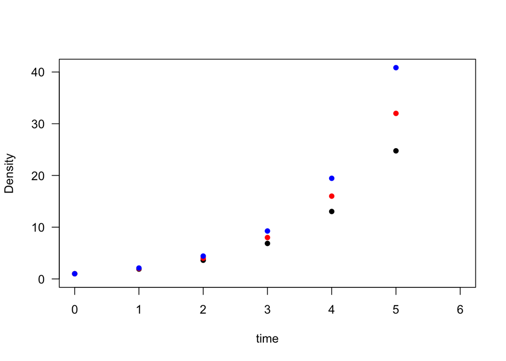

```r
lam1.9 <- c(1, 1.9, 3.61, 6.859, 13.0321, 24.76099)
lam2.0 <- c(1, 2, 4, 8, 16, 32)
lam2.1 <- c(1, 2.1, 4.41, 9.261, 19.4481, 40.84101)
times <- seq(from = 0, to = 5, by = 1)
n.timesteps <- length(times)
plot(x = NA, type = "n", xlim = c(0, n.timesteps), ylim = c(0, max(c(lam1.9, lam2.0, lam2.1))), xlab = "time", ylab = "Density", las = 1)
  points(x = times, y = lam1.9, col = "black", pch = 16)
  points(x = times, y = lam2.0, col = "red", pch = 16)
  points(x = times, y = lam2.1, col = "blue", pch = 16)
```

### 1.2

Plot the numbers aclculated in exercise 1.1 as ln($N$) versus time. Sketch (by hand, by eye) the function that best approximates one of the datasets (try for $\lambda = 2$), and visually estimate what the parameters of that function might be. What is the nature of the function, and how do its parameters relate to the original construction of the set of numbers in exercise 1.1?

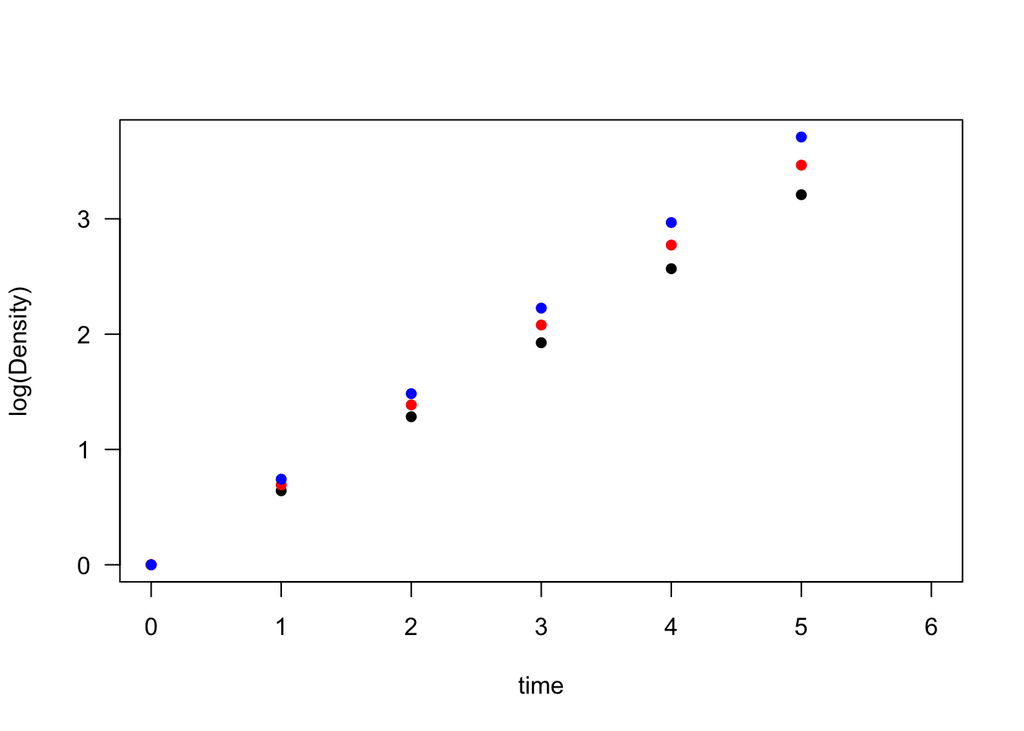

```r
log1.9 <- log(lam1.9)
log2.0 <- log(lam2.0)
log2.1 <- log(lam2.1)
plot(x = NA, type = "n", xlim = c(0, n.timesteps), ylim = c(0, max(c(log1.9, log2.0, log2.1))), xlab = "time", ylab = "log(Density)", las = 1)
  points(x = times, y = log1.9, col = "black", pch = 16)
  points(x = times, y = log2.0, col = "red", pch = 16)
  points(x = times, y = log2.1, col = "blue", pch = 16)
```

### 1.3

Derive an equation for doubling time in an exponentially growing population, and derive one for tripling time.

If $N(t) = N(0)e^{rt}$, and we want to double or triple the initial population, we respectively seek the ratios $\frac{N(t)}{N(0)} = 2$ and $\frac{N(t)}{N(0)} = 3$. How long that takes means we must then solve for $t$. If $x = e^{rt}$, solving for $t$ would require taking the log (natural) of both sides, then dividing both sides by $r$, leaving us with $\frac{\log (x)}{r} = t$. For doubling time let $x = 2$ and for tripling time let $x = 3$.

### 1.4

Plot the values computed in exercise 1.1 on a graph of $N_{t+1}$ versus $N_t$, where $N$ is the number of individuals and $t$ is time. What is the shape of the plotted points? What would bet he values of a regression coefficient through the points? How does that relate to the original value of $\lambda$?

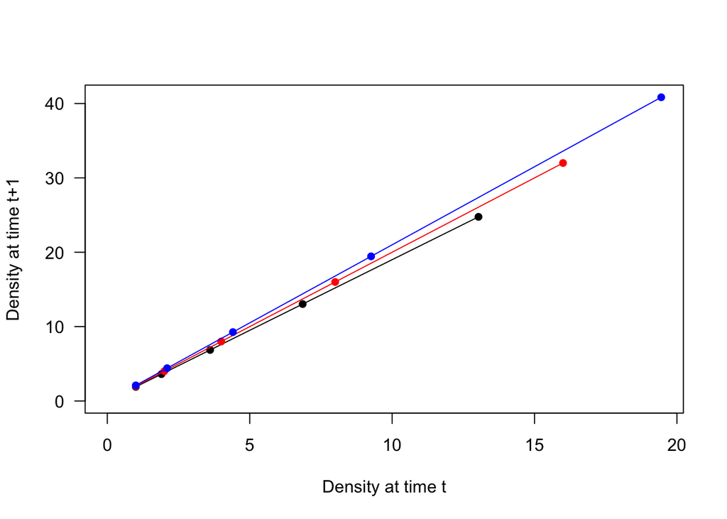

```r
plot(x = NA, type = "n", xlim = c(0, max(c(lam1.9[-n.timesteps], lam2.0[-n.timesteps], lam2.1[-n.timesteps]))), ylim = c(0, max(c(lam1.9, lam2.0, lam2.1))), xlab = "Density at time t", ylab = "Density at time t+1" , las = 1)
  points(x = lam1.9[-n.timesteps], y = lam1.9[-1], col = "black", pch = 16)
  lines(x = lam1.9[-n.timesteps], y = lam1.9[-1], col = "black")
  points(x = lam2.0[-n.timesteps], y = lam2.0[-1], col = "red", pch = 16)
  lines(x = lam2.0[-n.timesteps], y = lam2.0[-1], col = "red")
  points(x = lam2.1[-n.timesteps], y = lam2.1[-1], col = "blue", pch = 16)
  lines(x = lam2.1[-n.timesteps], y = lam2.1[-1], col = "blue")
```

### 1.5

The human population on a small island nation is said to be doubling every 20 years. What would be the value of $r$ (assuming an exponential model)? In $2 = \frac{N(20)}{N(0)} = e^{r(20)}$, then we are trying to solve for $r$. In this case, we take the natural log of both sides and divide by $t = 20$, giving $r = \frac{\log (2)}{20} = 0.03465736$.

### 1.6

Using the differential form (i.e., continuous time), suppose that $r = 0.5$. Compute $N$ as a function of $t$, again beginning with a single individual. Do the same for $r = 1.5$ and for $r = 1$. Graph all three results, and think about the pattern.

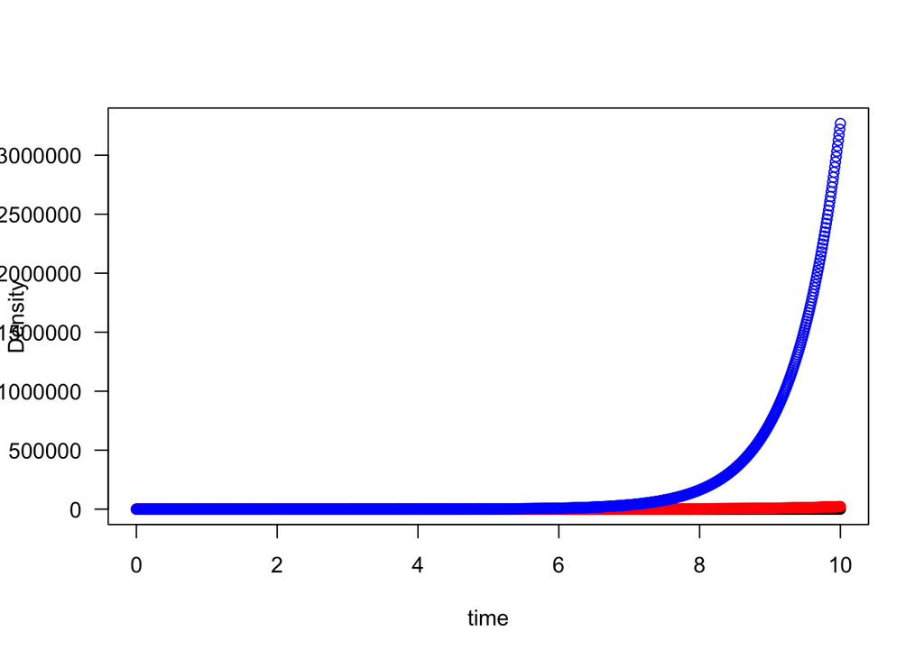

```r
# Use the solution to the exponetial equation to solve for N at time t from an inital N of 1 (here, until t = 10)
times <- seq(from = 0, to = 10, by = 0.01)
r0.5 <- 1*exp(0.5*times)
r1.0 <- 1*exp(1.0*times)
r1.5 <- 1*exp(1.5*times)
plot(x = NA, type = "n", xlim = c(0, 10), ylim = c(0, max(r1.5)), xlab = "time", ylab = "Density", las = 1)
  points(x = times, y = r0.5, col = "black", pch = 1)
  points(x = times, y = r1.0, col = "red", pch = 1)
  points(x = times, y = r1.5, col = "blue", pch = 1)
```

### 1.7

Plot the derivative (which you can approximate by subtracting the current $N$ from its successive on and dividing by the change in time) as a function of $N$ for the data calculated in exercise 1.6 (use a small time interval, e.g., 0.01).

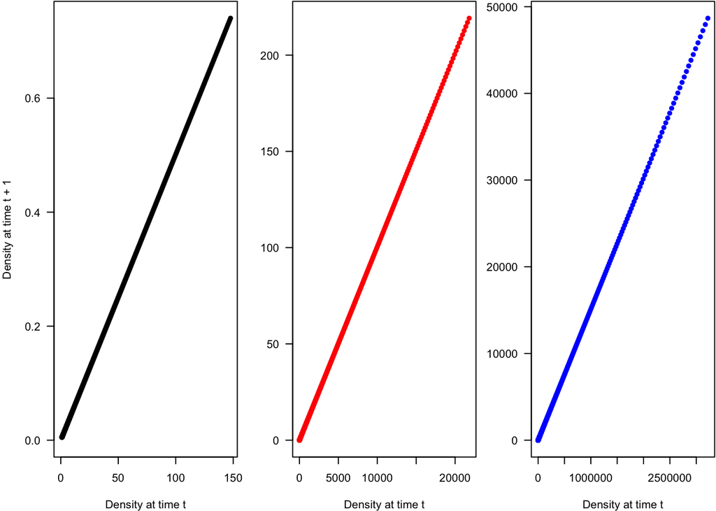

```r
len.t <- length(times)
#  len.t # we know how many ts we calcualtes
r0.5t <- r0.5[-len.t]
r0.5t1 <- r0.5[-1]
diff0.5 <- r0.5t1 - r0.5t
diff1.0 <- r1.0[-1] - r1.0[-len.t]
diff1.5 <- r1.5[-1] - r1.5[-len.t]
par(mar = c(4, 4, 0.1, 0.1), mfrow = c(1, 3))
plot(x = r0.5t, y = diff0.5, pch = 16, xlim = c(0, max(r0.5t)), ylim = c(0, max(diff0.5)), xlab = "Density at time t", ylab = "Density at time t + 1", las = 1)
plot(x = r1.0[-len.t], y = diff1.0, pch = 16, col = "red", xlim = c(0, max(r1.0[-len.t])), ylim = c(0, max(diff1.0)), xlab = "Density at time t", ylab = "", las = 1)
plot(x = r1.5[-len.t], y = diff1.5, pch = 16, col = "blue", xlim = c(0, max(r1.5[-len.t])), ylim = c(0, max(diff1.5)), xlab = "Density at time t", ylab = "", las = 1)
```